# Ch. 06

JAMM

19/07/2021

# Naive Bayes

To predict party affiliation. Looking for common voting paterns from previous elections. Train wether a congressperson was a D or a R. USARLO PARA CLASIFICAR SI UNA ACCION ES RENTABLE O NO\

```
## # A tibble: 435 x 17
##    Class V1    V2    V3    V4    V5    V6    V7    V8    V9    V10   V11   V12
##    <fct> <fct> <fct> <fct> <fct> <fct> <fct> <fct> <fct> <fct> <fct> <fct> <fct>
##  1 repu… n     y     n     y     y     y     n     n     n     y     <NA>  y
##  2 repu… n     y     n     y     y     y     n     n     n     n     n     y
##  3 demo… <NA>  y     y     <NA>  y     y     n     n     n     n     y     n
##  4 demo… n     y     y     n     <NA>  y     n     n     n     n     y     n
##  5 demo… y     y     y     n     y     y     n     n     n     n     y     <NA>
##  6 demo… n     y     y     n     y     y     n     n     n     n     n     n
##  7 demo… n     y     n     y     y     y     n     n     n     n     n     n
##  8 repu… n     y     n     y     y     y     n     n     n     n     n     n
##  9 repu… n     y     n     y     y     y     n     n     n     n     n     y
## 10 demo… y     y     y     n     n     n     y     y     y     n     n     n
## # … with 425 more rows, and 4 more variables: V13 <fct>, V14 <fct>, V15 <fct>,
## #   V16 <fct>
```

```r
#First argument  of the  function  is the  name of the data. Second is the function we will apply to it.
map_dbl(votesTib, ~sum(is.na(.)))
```

```
## Class    V1    V2    V3    V4    V5    V6    V7    V8    V9   V10   V11   V12
##     0    12    48    11    11    15    11    14    15    22     7    21    31
##   V13   V14   V15   V16
##    25    17    28   104
```

We can handle the NAs in 2 ways with Naive Bayes. One, ommiting them but using them to train the model. Two, ommiting it entirely.\ If we want to count the number of ‘y’.

```
## Class    V1    V2    V3    V4    V5    V6    V7    V8    V9   V10   V11   V12
##     0   187   195   253   177   212   272   239   242   207   216   150   171
##   V13   V14   V15   V16
##   209   248   174   269
```

### 6.2.2 Plotting Data

We take into consideration that we are plotting categorical data against each other.

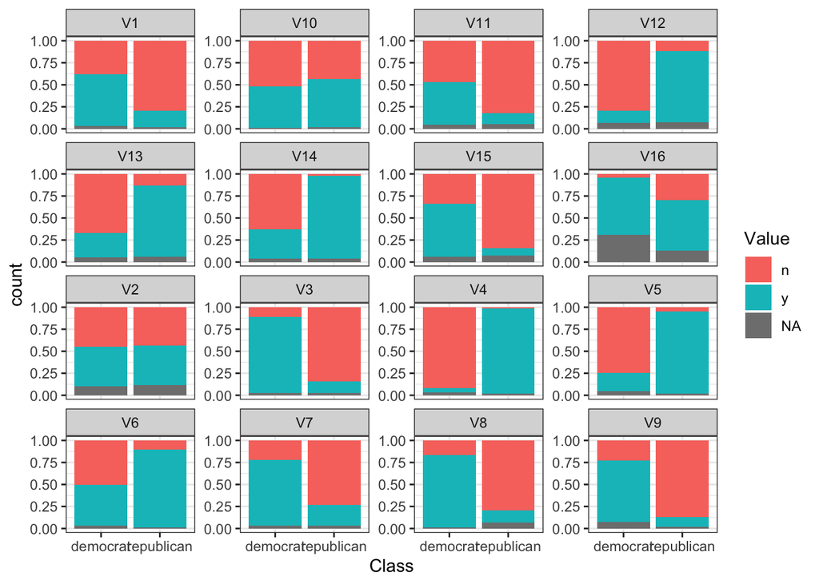

### 6.2.3 Training Model

Class variable -> classification target for makeClassifTask()\ The algorithm we’ll use is “classif.naiveBayes”.

We now use 10-fold CV. We repeated 50 times.\ We ask for the false and positive rates in the measures argument.

[output not shown]

[output not shown]

[output not shown]

[output not shown]

[output not shown]

[output not shown]

[output not shown]

[output not shown]

[output not shown]

[output not shown]

[output not shown]

[output not shown]

[output not shown]

[output not shown]

[output not shown]

[output not shown]

[output not shown]

[output not shown]

[output not shown]

[output not shown]

[output not shown]

[output not shown]

[output not shown]

[output not shown]

[output not shown]

[output not shown]

[output not shown]

[output not shown]

[output not shown]

[output not shown]

[output not shown]

[output not shown]

[output not shown]

[output not shown]

[output not shown]

[output not shown]

[output not shown]

[output not shown]

[output not shown]

[output not shown]

[output not shown]

[output not shown]

[output not shown]

[output not shown]

[output not shown]

[output not shown]

[output not shown]

[output not shown]

[output not shown]

[output not shown]

[output not shown]

[output not shown]

[output not shown]

[output not shown]

[output not shown]

[output not shown]

[output not shown]

[output not shown]

[output not shown]

[output not shown]

[output not shown]

[output not shown]

[output not shown]

[output not shown]

[output not shown]

[output not shown]

[output not shown]

[output not shown]

[output not shown]

[output not shown]

[output not shown]

[output not shown]

[output not shown]

[output not shown]

[output not shown]

[output not shown]

[output not shown]

[output not shown]

[output not shown]

[output not shown]

[output not shown]

[output not shown]

[output not shown]

[output not shown]

[output not shown]

[output not shown]

[output not shown]

[output not shown]

[output not shown]

[output not shown]

[output not shown]

[output not shown]

[output not shown]

[output not shown]

[output not shown]

[output not shown]

[output not shown]

[output not shown]

[output not shown]

[output not shown]

[output not shown]

[output not shown]

[output not shown]

[output not shown]

[output not shown]

[output not shown]

[output not shown]

[output not shown]

[output not shown]

[output not shown]

[output not shown]

[output not shown]

[output not shown]

[output not shown]

[output not shown]

[output not shown]

[output not shown]

[output not shown]

[output not shown]

[output not shown]

[output not shown]

[output not shown]

[output not shown]

[output not shown]

[output not shown]

[output not shown]

[output not shown]

[output not shown]

[output not shown]

[output not shown]

[output not shown]

[output not shown]

[output not shown]

[output not shown]

[output not shown]

[output not shown]

[output not shown]

[output not shown]

[output not shown]

[output not shown]

[output not shown]

[output not shown]

[output not shown]

[output not shown]

[output not shown]

[output not shown]

[output not shown]

[output not shown]

[output not shown]

[output not shown]

[output not shown]

[output not shown]

[output not shown]

[output not shown]

[output not shown]

[output not shown]

[output not shown]

[output not shown]

[output not shown]

[output not shown]

[output not shown]

[output not shown]

[output not shown]

[output not shown]

[output not shown]

[output not shown]

[output not shown]

[output not shown]

[output not shown]

[output not shown]

[output not shown]

[output not shown]

[output not shown]

[output not shown]

[output not shown]

[output not shown]

[output not shown]

[output not shown]

[output not shown]

[output not shown]

[output not shown]

[output not shown]

[output not shown]

[output not shown]

[output not shown]

[output not shown]

[output not shown]

[output not shown]

[output not shown]

[output not shown]

[output not shown]

[output not shown]

[output not shown]

[output not shown]

[output not shown]

[output not shown]

[output not shown]

[output not shown]

[output not shown]

[output not shown]

[output not shown]

[output not shown]

[output not shown]

[output not shown]

[output not shown]

[output not shown]

[output not shown]

[output not shown]

[output not shown]

[output not shown]

[output not shown]

[output not shown]

[output not shown]

[output not shown]

[output not shown]

[output not shown]

[output not shown]

[output not shown]

[output not shown]

[output not shown]

[output not shown]

[output not shown]

[output not shown]

[output not shown]

[output not shown]

[output not shown]

[output not shown]

[output not shown]

[output not shown]

[output not shown]

[output not shown]

[output not shown]

[output not shown]

[output not shown]

[output not shown]

[output not shown]

[output not shown]

[output not shown]

[output not shown]

[output not shown]

[output not shown]

[output not shown]

[output not shown]

[output not shown]

[output not shown]

[output not shown]

[output not shown]

[output not shown]

[output not shown]

[output not shown]

[output not shown]

[output not shown]

[output not shown]

[output not shown]

[output not shown]

[output not shown]

[output not shown]

[output not shown]

[output not shown]

[output not shown]

[output not shown]

[output not shown]

[output not shown]

[output not shown]

[output not shown]

[output not shown]

[output not shown]

[output not shown]

[output not shown]

[output not shown]

[output not shown]

[output not shown]

[output not shown]

[output not shown]

[output not shown]

[output not shown]

[output not shown]

[output not shown]

[output not shown]

[output not shown]

[output not shown]

[output not shown]

[output not shown]

[output not shown]

[output not shown]

[output not shown]

[output not shown]

[output not shown]

[output not shown]

[output not shown]

[output not shown]

[output not shown]

[output not shown]

[output not shown]

[output not shown]

[output not shown]

[output not shown]

[output not shown]

[output not shown]

[output not shown]

[output not shown]

[output not shown]

[output not shown]

[output not shown]

[output not shown]

[output not shown]

[output not shown]

[output not shown]

[output not shown]

[output not shown]

[output not shown]

[output not shown]

[output not shown]

[output not shown]

[output not shown]

[output not shown]

[output not shown]

[output not shown]

[output not shown]

[output not shown]

[output not shown]

[output not shown]

[output not shown]

[output not shown]

[output not shown]

[output not shown]

[output not shown]

[output not shown]

[output not shown]

[output not shown]

[output not shown]

[output not shown]

[output not shown]

[output not shown]

[output not shown]

[output not shown]

[output not shown]

[output not shown]

[output not shown]

[output not shown]

[output not shown]

[output not shown]

[output not shown]

[output not shown]

[output not shown]

[output not shown]

[output not shown]

[output not shown]

[output not shown]

[output not shown]

[output not shown]

[output not shown]

[output not shown]

[output not shown]

[output not shown]

[output not shown]

[output not shown]

[output not shown]

[output not shown]

[output not shown]

[output not shown]

[output not shown]

[output not shown]

[output not shown]

[output not shown]

[output not shown]

[output not shown]

[output not shown]

[output not shown]

[output not shown]

[output not shown]

[output not shown]

[output not shown]

[output not shown]

[output not shown]

[output not shown]

[output not shown]

[output not shown]

[output not shown]

[output not shown]

[output not shown]

[output not shown]

[output not shown]

[output not shown]

[output not shown]

[output not shown]

[output not shown]

[output not shown]

[output not shown]

[output not shown]

[output not shown]

[output not shown]

[output not shown]

[output not shown]

[output not shown]

[output not shown]

[output not shown]

[output not shown]

[output not shown]

[output not shown]

[output not shown]

[output not shown]

[output not shown]

[output not shown]

[output not shown]

[output not shown]

[output not shown]

[output not shown]

[output not shown]

[output not shown]

[output not shown]

[output not shown]

[output not shown]

[output not shown]

[output not shown]

[output not shown]

[output not shown]

[output not shown]

[output not shown]

[output not shown]

[output not shown]

[output not shown]

[output not shown]

[output not shown]

[output not shown]

[output not shown]

[output not shown]

[output not shown]

[output not shown]

[output not shown]

[output not shown]

[output not shown]

[output not shown]

[output not shown]

[output not shown]

[output not shown]

[output not shown]

[output not shown]

[output not shown]

[output not shown]

[output not shown]

[output not shown]

[output not shown]

[output not shown]

[output not shown]

[output not shown]

[output not shown]

[output not shown]

[output not shown]

[output not shown]

[output not shown]

[output not shown]

[output not shown]

[output not shown]

[output not shown]

[output not shown]

[output not shown]

[output not shown]

[output not shown]

[output not shown]

[output not shown]

[output not shown]

[output not shown]

[output not shown]

[output not shown]

[output not shown]

[output not shown]

[output not shown]

[output not shown]

[output not shown]

[output not shown]

[output not shown]

[output not shown]

[output not shown]

[output not shown]

[output not shown]

[output not shown]

[output not shown]

[output not shown]

[output not shown]

[output not shown]

[output not shown]

[output not shown]

[output not shown]

[output not shown]

[output not shown]

[output not shown]

[output not shown]

[output not shown]

[output not shown]

[output not shown]

[output not shown]

[output not shown]

[output not shown]

[output not shown]

[output not shown]

[output not shown]

[output not shown]

[output not shown]

[output not shown]

[output not shown]

[output not shown]

```
## Aggregated Result: mmce.test.mean=0.0983472,acc.test.mean=0.9016528,fpr.test.mean=0.0822574,fnr.test.mean=0.1085556
```

Prediction rate in accuracy (acc.)

```r
bayesCV$aggr
```

```
## mmce.test.mean  acc.test.mean  fpr.test.mean  fnr.test.mean
##     0.09834723     0.90165277     0.08225735     0.10855556
```

If we want to predict the political party of a new politician (not in original data).

```r
politician <- tibble(V1="n",V2="n",V3="y",V4="n",V5="n",V6V="y",V7V="y",V8="y",V9="y",V10="y",V11="n",V12="y",V13="n",V14="n",V15="y",V16="n")
politicianpred <- predict(bayesModel, newdata = politician)
getPredictionResponse(politicianpred)
```

```
## [1] democrat
## Levels: democrat republican
```

Now if we wrap our model inside getLearnerModel() function. What are the prior and likelihood probabilities?

```r
getLearnerModel(bayesModel)
```

```
##
## Naive Bayes Classifier for Discrete Predictors
##
## Call:
## naiveBayes.default(x = X, y = Y, laplace = laplace)
##
## A-priori probabilities:
## Y
##   democrat republican
##  0.6137931  0.3862069
##
## Conditional probabilities:
##             V1
## Y                    n         y
##   democrat   0.3953488 0.6046512
##   republican 0.8121212 0.1878788
##
##             V2
## Y                    n         y
##   democrat   0.4979079 0.5020921
##   republican 0.4932432 0.5067568
##
##             V3
## Y                    n         y
##   democrat   0.1115385 0.8884615
##   republican 0.8658537 0.1341463
##
##             V4
## Y                     n          y
##   democrat   0.94594595 0.05405405
##   republican 0.01212121 0.98787879
##
##             V5
## Y                     n          y
##   democrat   0.78431373 0.21568627
##   republican 0.04848485 0.95151515
##
##             V6
## Y                    n         y
##   democrat   0.5232558 0.4767442
```

[output cut: 36 more lines]

```
##
##             V14
## Y                     n          y
##   democrat   0.64980545 0.35019455
##   republican 0.01863354 0.98136646
##
##             V15
## Y                     n          y
##   democrat   0.36254980 0.63745020
##   republican 0.91025641 0.08974359
##
##             V16
## Y                     n          y
##   democrat   0.06486486 0.93513514
##   republican 0.34246575 0.65753425
```

# Strengths and Weaknesses

S: continuous and categorical variables, inexpensive computanioally, no hyperparamaters to tune, handle cases of missing data.\ W: Assumes continuous predictors variables distribute normal, that they are iid.

# SVM Algorithm

To build a classifier. Veremos un plano que separa los 1s de los 0s.\ Puede agregar una dimension mas para darnos el mejor hiperplano.Buenos para non-linear separable classes.\ SVM encuentra el hiperplano lineal optimo. (2 datos, el hiperplano es una linea, etc.). El algoritmo buscara el plano optimo que maximiza el margen alrededor del plano. El margen es la distancia alrededor del plano que toca el menor numero de casos. Los casos que tocan el margen se llaman SV. Nos ayudan a definir el boundary entre clases. (Ej. x = horas jugadas, y = money made, predict si boss bien o mal).\ Usaremos en muchas ocaciones “soft” margins que permiten algunos errores. Es un sacrificio de bias-variance contra los hard margins.

## Non-linear data anda SVM

# Model SVM

```
## # A tibble: 6 x 58
##    make address   all num3d   our  over remove internet order  mail receive
##   <dbl>   <dbl> <dbl> <dbl> <dbl> <dbl>  <dbl>    <dbl> <dbl> <dbl>   <dbl>
## 1  0       0.64  0.64     0  0.32  0      0        0     0     0       0
## 2  0.21    0.28  0.5      0  0.14  0.28   0.21     0.07  0     0.94    0.21
## 3  0.06    0     0.71     0  1.23  0.19   0.19     0.12  0.64  0.25    0.38
## 4  0       0     0        0  0.63  0      0.31     0.63  0.31  0.63    0.31
## 5  0       0     0        0  0.63  0      0.31     0.63  0.31  0.63    0.31
## 6  0       0     0        0  1.85  0      0        1.85  0     0       0
## # … with 47 more variables: will <dbl>, people <dbl>, report <dbl>,
## #   addresses <dbl>, free <dbl>, business <dbl>, email <dbl>, you <dbl>,
## #   credit <dbl>, your <dbl>, font <dbl>, num000 <dbl>, money <dbl>, hp <dbl>,
## #   hpl <dbl>, george <dbl>, num650 <dbl>, lab <dbl>, labs <dbl>, telnet <dbl>,
## #   num857 <dbl>, data <dbl>, num415 <dbl>, num85 <dbl>, technology <dbl>,
## #   num1999 <dbl>, parts <dbl>, pm <dbl>, direct <dbl>, cs <dbl>,
## #   meeting <dbl>, original <dbl>, project <dbl>, re <dbl>, edu <dbl>,
## #   table <dbl>, conference <dbl>, charSemicolon <dbl>, charRoundbracket <dbl>,
## #   charSquarebracket <dbl>, charExclamation <dbl>, charDollar <dbl>,
## #   charHash <dbl>, capitalAve <dbl>, capitalLong <dbl>, capitalTotal <dbl>,
## #   type <fct>
```

## 6.5.2 Tuning in parameters

Con esto sabremos que hiperparametros estan disponibles para tuning. Usamos getParamSet(). Nos dira cual es el valor definido, sino lo cambiamos; los constraints; si es necesario para el learner; si puede ser tuned.

```
##                        Type  len             Def
## type               discrete    - C-classifica...
## cost                numeric    -               1
## nu                  numeric    -             0.5
## class.weights numericvector <NA>               -
## kernel             discrete    -          radial
## degree              integer    -               3
## coef0               numeric    -               0
## gamma               numeric    -               -
## cachesize           numeric    -              40
## tolerance           numeric    -           0.001
## shrinking           logical    -            TRUE
## cross               integer    -               0
## fitted              logical    -            TRUE
## scale         logicalvector <NA>            TRUE
##                                           Constr Req Tunable Trafo
## type          C-classification,nu-classification   -    TRUE     -
## cost                                    0 to Inf   Y    TRUE     -
## nu                                   -Inf to Inf   Y    TRUE     -
## class.weights                           0 to Inf   -    TRUE     -
## kernel          linear,polynomial,radial,sigmoid   -    TRUE     -
## degree                                  1 to Inf   Y    TRUE     -
## coef0                                -Inf to Inf   Y    TRUE     -
## gamma                                   0 to Inf   Y    TRUE     -
## cachesize                            -Inf to Inf   -    TRUE     -
## tolerance                               0 to Inf   -    TRUE     -
## shrinking                                      -   -    TRUE     -
## cross                                   0 to Inf   -   FALSE     -
## fitted                                         -   -   FALSE     -
## scale                                          -   -    TRUE     -
```